# Session 3 — Propensity Scores and Matching

Propensity score · overlap · matching · balance · love plot · effect in the matched sample · Lab 3

Community Medicine Workshop

## Where we are

- Session 2: adjust in the **outcome model**
- Today: model the **treatment assignment** instead, and build **comparable groups** before looking at the outcome
- By the end you can:
  - estimate a **propensity score** and check **overlap**
  - **match** and check **balance**
  - estimate the effect in the matched sample

# Topic 1 — The propensity score

## Probability of enrolment

```r
ps_model <- glm(f_ps, data = htn, family = binomial)
htn$ps <- predict(ps_model, type = "response")
htn |> group_by(programme) |> summarise(min = round(min(ps), 2), mean = round(mean(ps), 2), max = round(max(ps), 2))
```

```
# A tibble: 2 × 4
  programme   min  mean   max
      <dbl> <dbl> <dbl> <dbl>
1         0  0.04  0.35  0.87
2         1  0.07  0.49  0.97
```

- **Propensity score** = P(enrolled | confounders). Two adults with the **same score** have, on average, the **same confounder distribution**: like a small randomised trial
- Include the **confounders** (and predictors of the outcome); **not** mediators, colliders or variables that only predict enrolment
- The aim is **balance**, not prediction: do **not** judge it by the AUC

## Overlap (positivity)

```r
ggplot(htn, aes(ps, fill = factor(programme, labels = c("Not enrolled", "Enrolled")))) + geom_density(alpha = 0.5) + scale_fill_manual(values = c(col_blue, col_red)) + labs(x = "Propensity score", fill = NULL)
```

The two distributions **overlap** over almost the whole range: for nearly every enrolled adult there are **comparable** non-enrolled adults. Regions **without** overlap cannot be compared without **extrapolation**.

## Overlap (positivity)

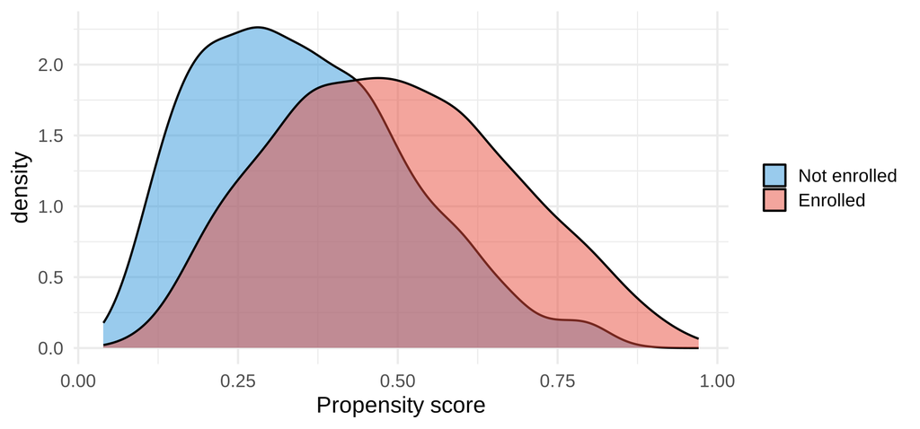

# Topic 2 — Matching

## Balance before matching

```r
bal.tab(f_ps, data = htn, un = TRUE, s.d.denom = "pooled")$Balance[, "Diff.Un", drop = FALSE] |> round(2)
```

```
                     Diff.Un
age                     0.43
sex_Male                0.00
education_None         -0.08
education_Primary      -0.04
education_Secondary+    0.11
urban                   0.12
bmi                     0.11
diabetes                0.12
baseline_sbp            0.63
```

**Standardised mean difference (SMD)**: difference in means divided by the SD. **Below 0.1** is the usual target. Here **baseline SBP 0.63** and **age 0.43**: far off.

## 1:1 nearest-neighbour matching

```r
m_out <- matchit(f_ps, data = htn, method = "nearest", distance = "glm", caliper = 0.2)
m_out
```

```
A `matchit` object
 - method: 1:1 nearest neighbor matching without replacement
 - distance: Propensity score [matching, caliper]
             - estimated with logistic regression
 - caliper: <distance> (0.037)
 - number of obs.: 3000 (original), 2114 (matched)
 - target estimand: ATT
 - covariates: age, sex, education, urban, bmi, diabetes, baseline_sbp
```

- Each enrolled adult is paired with the **non-enrolled adult with the closest score**; the **caliper** (0.2 SD) refuses poor matches
- **2,114 adults (1,057 pairs)** remain; **172 enrolled** adults found no match
- No outcome data are used: the design is fixed **before** looking at SBP

## Balance after matching

```r
love.plot(m_out, thresholds = 0.1, abs = TRUE, stars = "raw")
```

```r
bal.tab(m_out, un = TRUE)$Balance[c("age", "diabetes", "baseline_sbp"), c("Diff.Un", "Diff.Adj")] |> round(2)
```

```
             Diff.Un Diff.Adj
age             0.42     0.05
diabetes        0.12     0.01
baseline_sbp    0.63     0.06
```

All SMDs are now **below 0.1** (baseline SBP 0.63 → 0.06). Judge matching by **balance**, never by p-values. If balance is poor, **change the propensity model** (add interactions, curves) and match again.

## Balance after matching

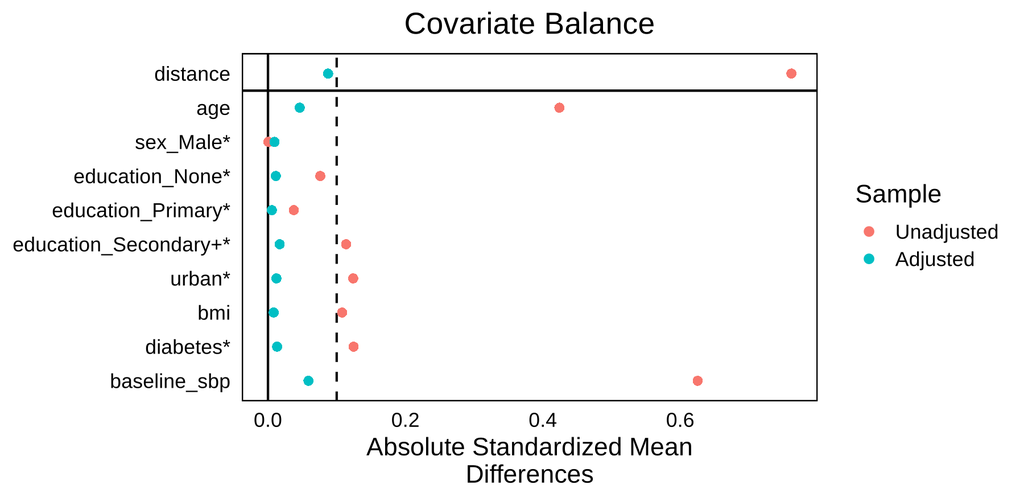

# Topic 3 — The effect

## In the matched sample

```r
md <- match.data(m_out)
fit_m <- lm(sbp_12m ~ programme, data = md, weights = weights)
round(coeftest(fit_m, vcov. = vcovCL, cluster = ~subclass)["programme", 1:2], 2)
```

```
  Estimate Std. Error
     -5.94       0.51
```

## Strengths and limits

| Strength | Limit |
| --- | --- |
| Separates **design** from **outcome analysis** | Only **measured** confounders are balanced |
| **Balance** is visible and checkable | Discards unmatched people (precision, target population) |
| Easy to explain | Many choices (caliper, ratio, replacement): **pre-specify** |

## 🔧 Switch to R — Lab 3

**File:** `causal-workshop/labs/lab3_match.R`

- propensity score and overlap plot
- matching with a caliper, balance table and love plot
- effect in the matched data

**Time:** 40 minutes · answer the Q questions in the comments

## Self-check quiz (1/5)

What is a propensity score?

- The probability of the outcome, given the exposure and the measured confounders
- The number of confounders on which two adults in the data agree exactly
- The share of the outcome variance that the exposure explains in the model
- The probability of receiving the exposure, given the measured confounders

## Self-check quiz (2/5)

How should you judge whether propensity-score matching has worked?

- By covariate balance, e.g. standardised differences below 0.1
- By the AUC of the propensity model, which should be above 0.8
- By the p-value of the exposure in the matched outcome model
- By the number of adults that are kept in the matched sample

## Self-check quiz (3/5)

The propensity distributions of the two groups hardly overlap. What does this mean?

- The propensity model is correct, as it discriminates well between the two groups
- Some adults have no comparable counterpart, so their effect is not estimable
- The exposure has a strong effect on the outcome in most adults of the cohort
- Matching will work especially well, because the two groups are so distinct

## Self-check quiz (4/5)

In 1:1 matching, 172 enrolled adults found no match within the caliper. What is the consequence?

- The estimate is biased by the caliper, which should therefore be removed
- The 172 adults should be matched to the nearest adult, whatever the distance
- Nothing follows, since dropped adults do not affect a matched analysis
- The estimate applies to the matched enrolled adults, a changed target

## Self-check quiz (5/5)

Which variables belong in the propensity-score model?

- Confounders measured before the exposure, chosen from the DAG
- Mediators such as adherence, since they predict the outcome well
- Colliders such as clinic visits, since they predict enrolment well
- All the available variables, selected by a stepwise procedure

## Score and take-home

**Your score:**

- **Propensity score** = P(exposure | confounders)
- Check **overlap** (positivity) first
- **Match**, then check **balance** (SMD < 0.1, love plot)
- Estimate in the matched data with **pair-clustered SE**
- Matching targets the **ATT** and balances only **measured** confounders

**Next:** Session 4: inverse probability weighting